# Exploration of Red Wine Quality by Jonathan Allen

```
##    Min. 1st Qu.  Median    Mean 3rd Qu.    Max.
##   2.740   3.210   3.310   3.311   3.400   4.010
```

Almost all of the wines have a pH between 3 and 4, which are the acidities of orange juice and tomato juice, respectively (2). Keep in mind that an acidity of 7 considered neutral (neither acid nor base), and is the acidity of pure water. Another point of note is that the pH scale is a log_10 scale, meaning that a pH 3.0 is ten times more acidic than a pH of 4.0.

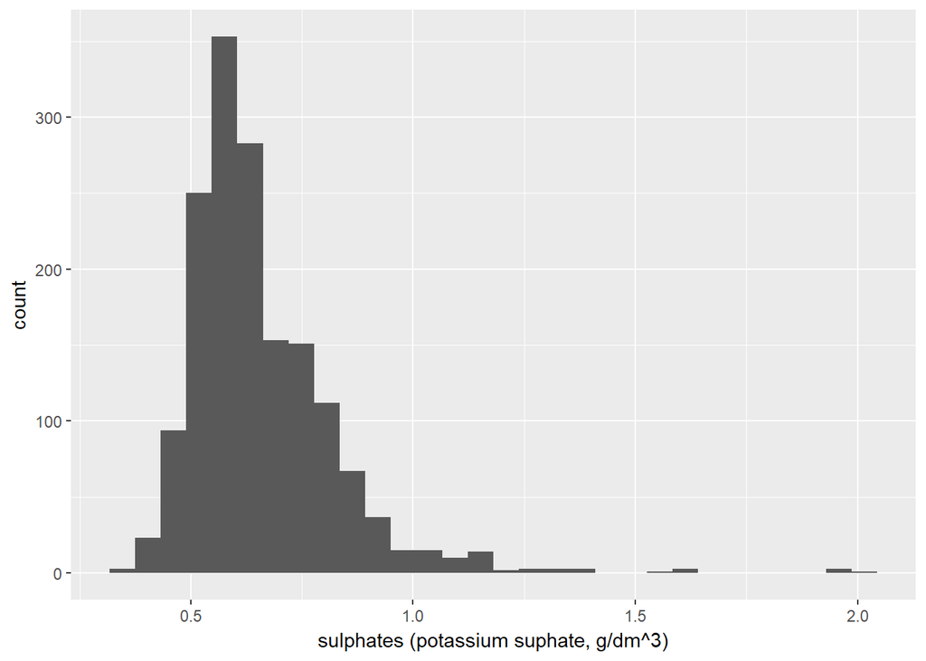

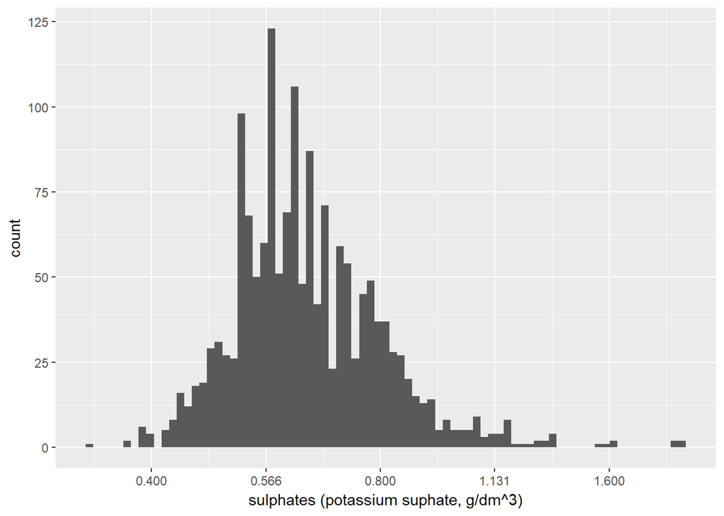

```
##    Min. 1st Qu.  Median    Mean 3rd Qu.    Max.
##  0.3300  0.5500  0.6200  0.6581  0.7300  2.0000
```

Transforming the long-tailed graph does look a little better. Almost all of the wines have fewer than 1 gram of suphates per dm^3, but there is at least one wine with twice that.

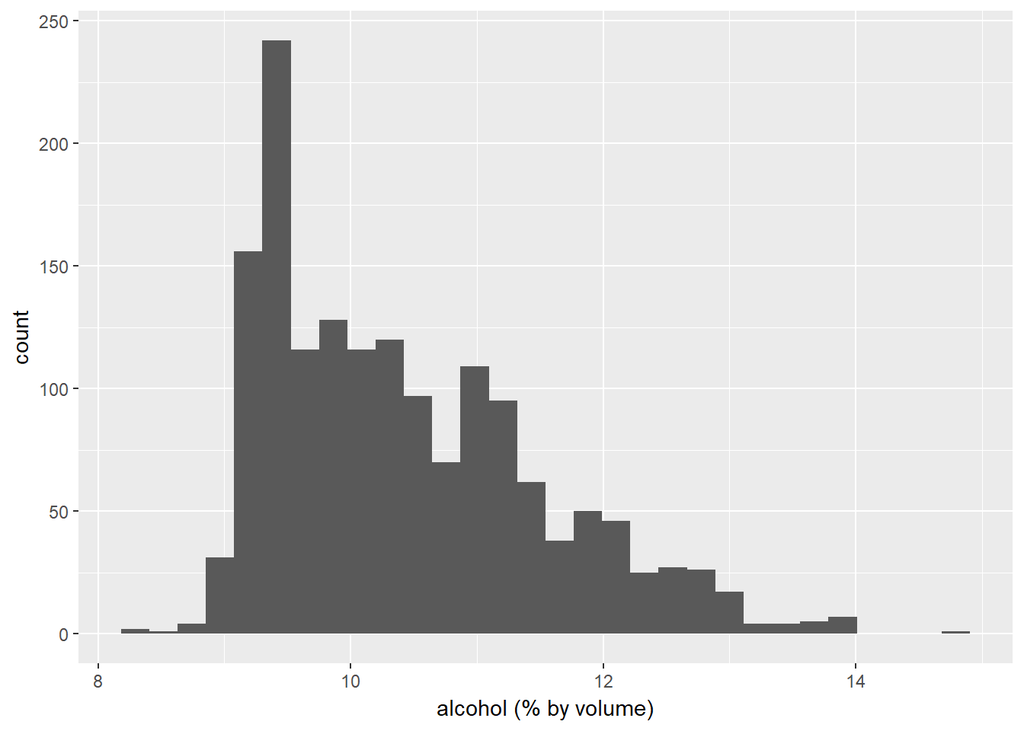

```
##    Min. 1st Qu.  Median    Mean 3rd Qu.    Max.
##    8.40    9.50   10.20   10.42   11.10   14.90
```

Most of the wines have an alcohol content between 9 and 12 percent. The plot is also skewed to the right.

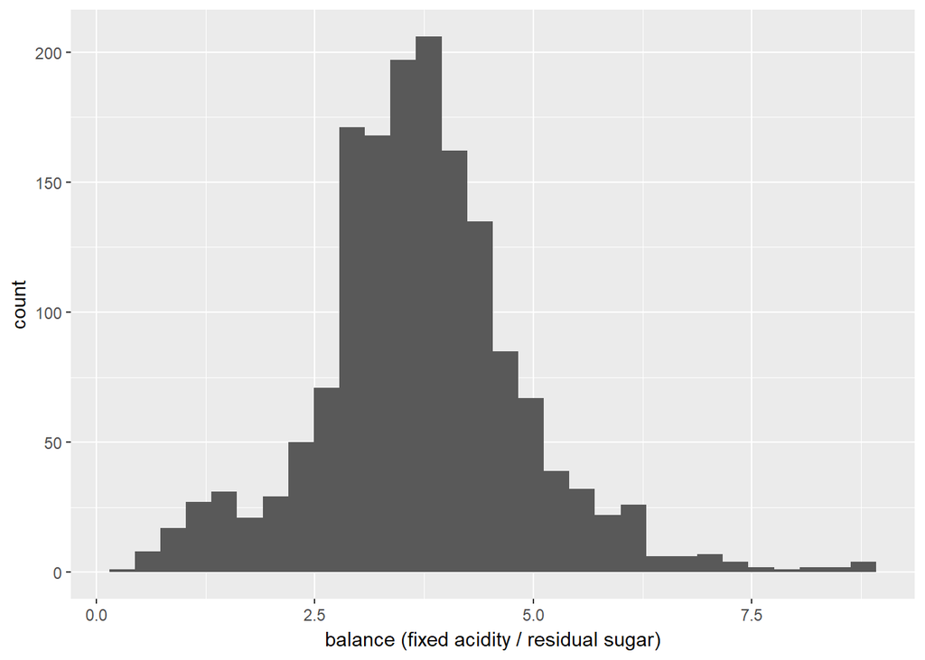

```
##    Min. 1st Qu.  Median    Mean 3rd Qu.    Max.
##  0.4029  3.0223  3.6667  3.7023  4.3179  8.8889
```

Most of the wines have 2.5-5.0 times as much tartaric acid (fixed acidity) as residual sugar.

# Univariate Analysis

### What is the structure of your dataset?

There are 1,599 wines in the data set. Each wine has been rated on a 1-10 scale (the recorded score is the median of at least 3 ratings given by wine experts) and has been measured in 11 different chemical attributes. The only true categorical variable is the wine’s quality, with 10 being the best wine and 1 being the worst.

More than 80% of the wines have a rating of either 5 or 6.

### What is/are the main feature(s) of interest in your dataset?

From research about wine, it is clear that the amount of acidity itself, or the amount of residual sugar itself is not an indicator of a high quality wine. What matters is ‘balance’ (3). So, one major feature of interest is to see whether a certain ratio of acidity (my guess is that fixed acidity is what to look at) to residual sugar correlates with a higher quality wine.

So, I anticipate that balance (fixed acidity / residual sugar) and quality are the main features of interest.

### What other features in the dataset do you think will help support your investigation into your feature(s) of interest?

I think that alcohol content, volatile acidity, and citric acid will also play a part in refining the model. I’ll also check the other variables, but I anticipate them having less of a role.

Since density varies so little betweeen samples, and it has a moderate correlation with both fixed acidity and alcohol, I will not be looking at density more closely.

Similarly, pH has a moderate negative correlation with fixed acitity and citric acid, and a positive correlation with volatile acidity. And overall, pH measures the same thing, acidity. With so many measures of acidity, I think it’s safe to pull pH out and keep the other three measures of acidity, since they are more specific.

### Did you create any new variables from existing variables in the dataset?

I created a variable called ‘balance’, which is the ratio between fixed acidity and residual sugar.

I also broke up the wines into buckets based on alcohol percentage, split at 20th percentile marks.

Lastly, I created a copy of the ‘quality’ column, with a datatype of factor. This was done largely for convenience, so I could do any desired mathematics off the one, and use the other as a categorical variable more easily.

### Of the features you investigated, were there any unusual distributions? Did you perform any operations on the data to tidy, adjust, or change the form of the data? If so, why did you do this?

There were a number of initial histograms that were skewed to the right (none were skewed to the left), and so I used log transformations on them. These were residual sugar, chlorides, free sulfur dioxide, total sulfur dioxide, and sulphates. I did so to get a better look at what was happening at the peaks.

I also noticed that, though the distributions of the chemical properties of the wines would intuitively be continuous, as the binwidth got smaller, they started to look discrete, due to the number of samples, and the rounding of the recorded data.

# Bivariate Plots Section

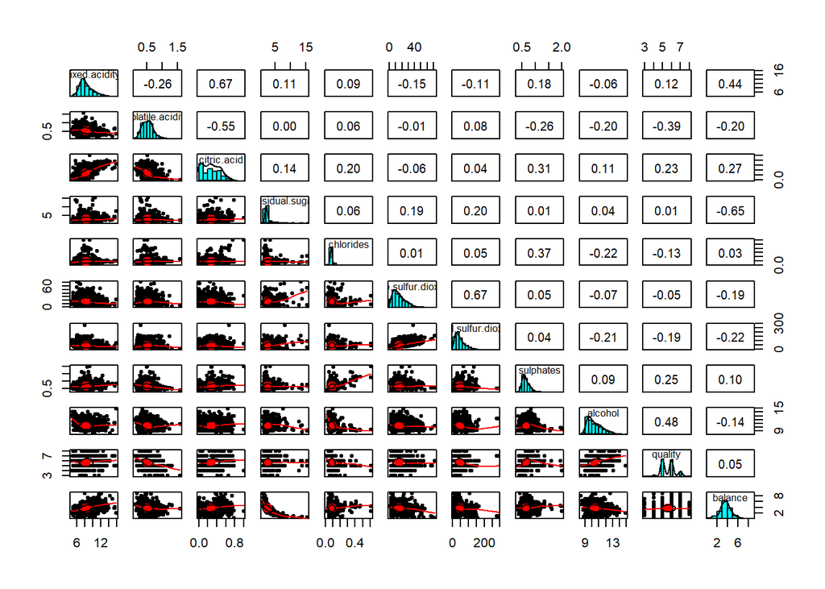

```
##  [1] "fixed.acidity"        "volatile.acidity"     "citric.acid"
##  [4] "residual.sugar"       "chlorides"            "free.sulfur.dioxide"
##  [7] "total.sulfur.dioxide" "density"              "pH"
## [10] "sulphates"            "alcohol"              "quality"
## [13] "quality.f"            "alcohol.bucket"       "balance"
```

Wow! My calculation of ‘balance’ has almost no correlation to quality. There goes my bright idea.

Also surprising to me, the strongest correlation indicated from this scatterplot matrix is alcohol % (moderate positive correlation), followed by volatile acidity (weak negative correlation). The latter was not surprising.

From here, I want to look at the relationship between quality and some of the other variables, particularly those with a higher correlation with quality. I would also like to look at some of the correlations between variables that are *not* quality, to get a better picture of what’s going on between them.

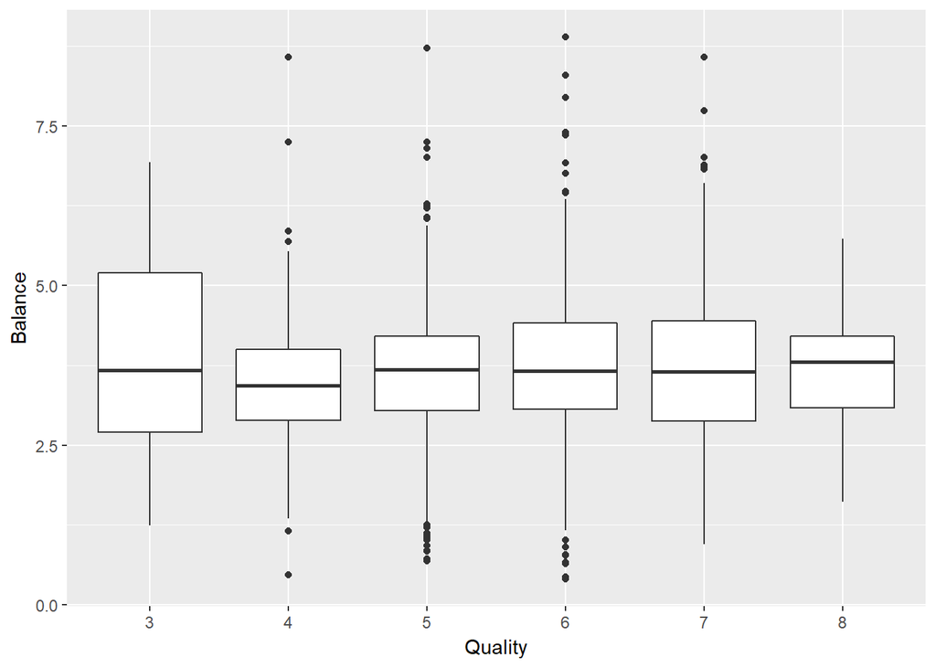

Yep. Looks like no correlation.

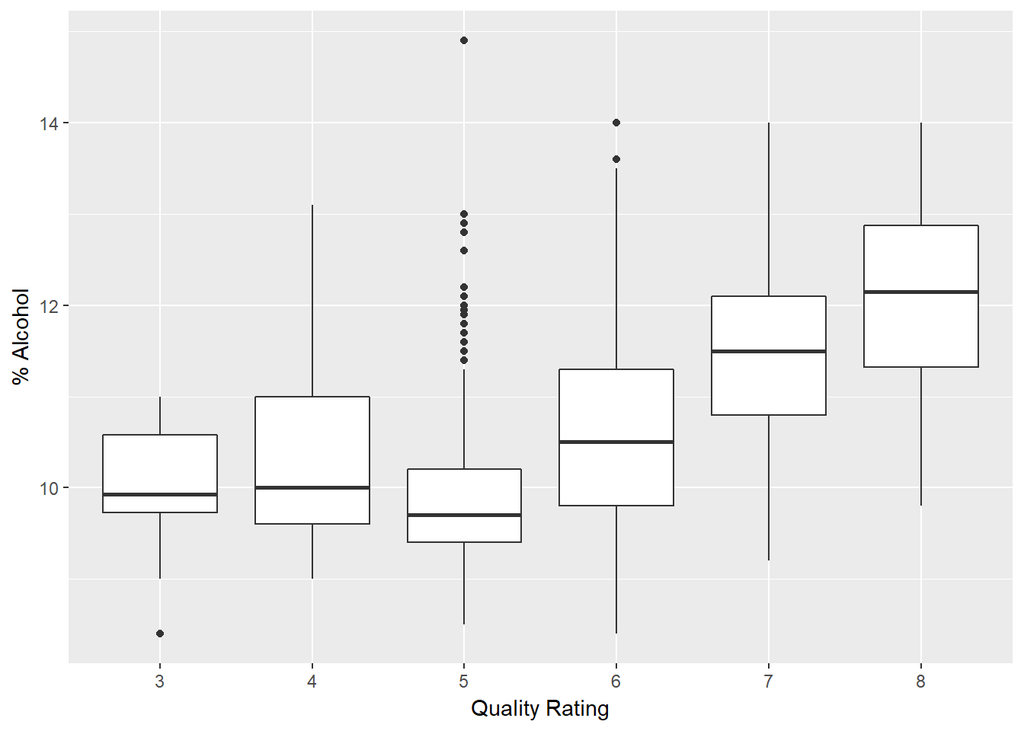

Here, the moderate positive correlation between % alcohol and quality is easy to see. One thing that stands out is the smaller interquartile range of the quality rating of 5. I wonder if 9.5-10% alcohol is fairly easy to achieve for wine, such that many wines fall there. Along with rating 6, this rating includes 80% of all the wines in the data set, so that’s a very highly-populated and small interquartile range.

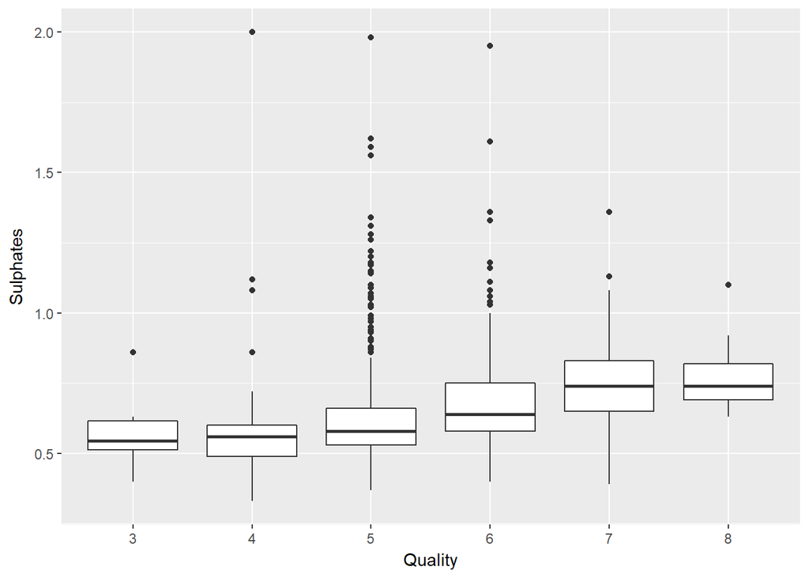

There are a lot of outliers on this plot, but you can still see the weak positive correlation.

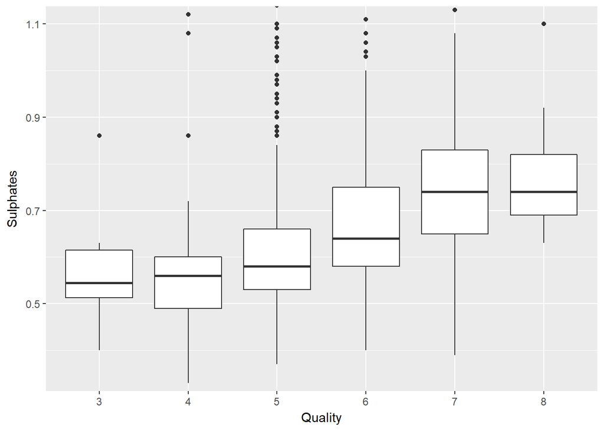

There, it’s much easier to see after zooming in, particularly if you look at the median lines. But, all those outliers make for a weaker correlation.

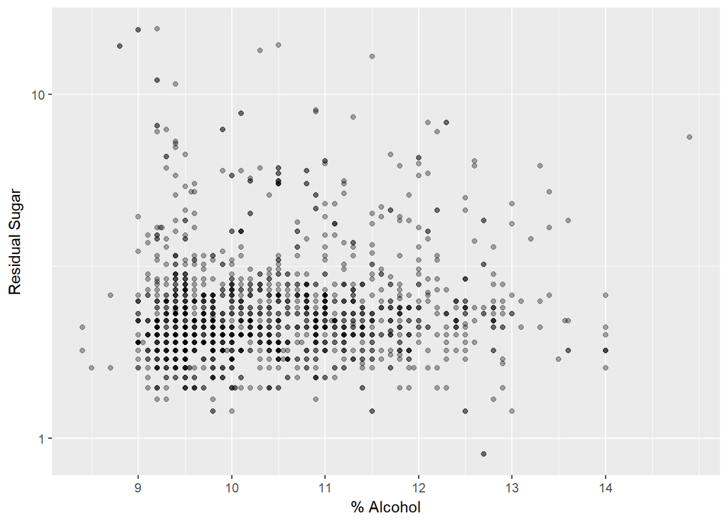

Residual sugar and alcohol actual have almost zero correlation (0.04 correlation coefficient, according to the scatterplot matrix), which this plot corroborates. Though I was hoping to find a stronger correlation, this result does makes sense in light of the fact that different grapes have differing sugar content, which means that different wines start with different levels of sugar.

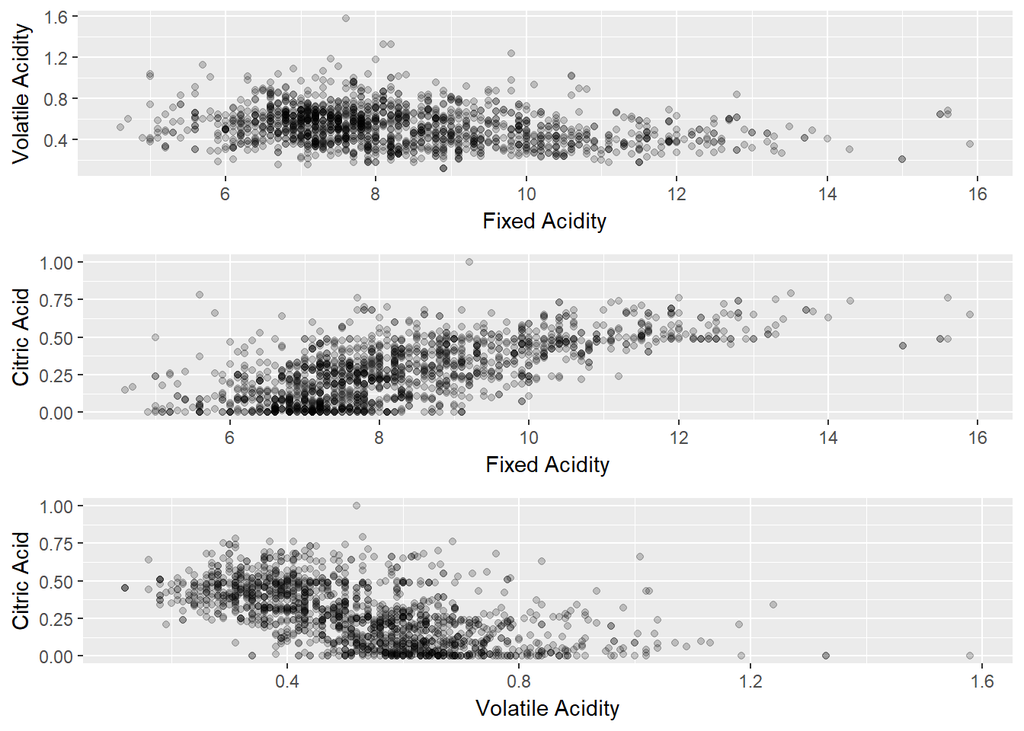

It’s interesting that the acidities correlate in different directions. I would have thought that more acidity would have meant higher values in all categories of acidity. However, fixed acidity and volatile acidity have a weak negative correlation, which wasn’t intuitive to me. Fixed acidity and citric acid have a strong positive correlation. And citric acid and volatile acidity have a moderate negative correlation.

This second relationship makes sense, thinking back to the description of the attributes. Citric acid gives ‘freshness’ and flavor, which is generally good, whereas too much volatile acidity results in an ‘unpleasant, vinegar taste’.

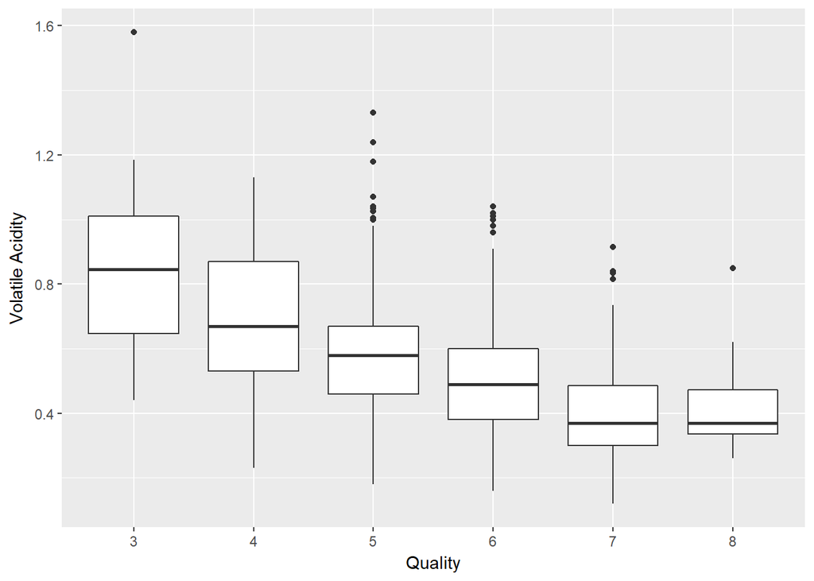

Here, you can see the weak (almost moderate) negative correlation between volatile acidity and quality.

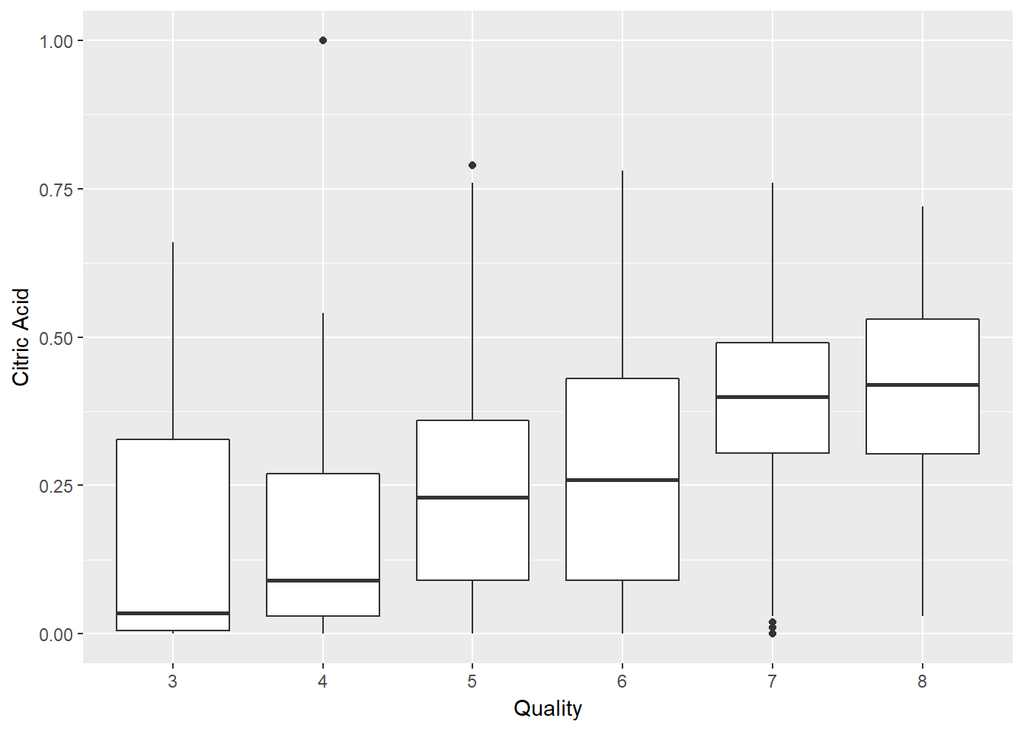

And this is the weak positive relationship between quality and citric acid.

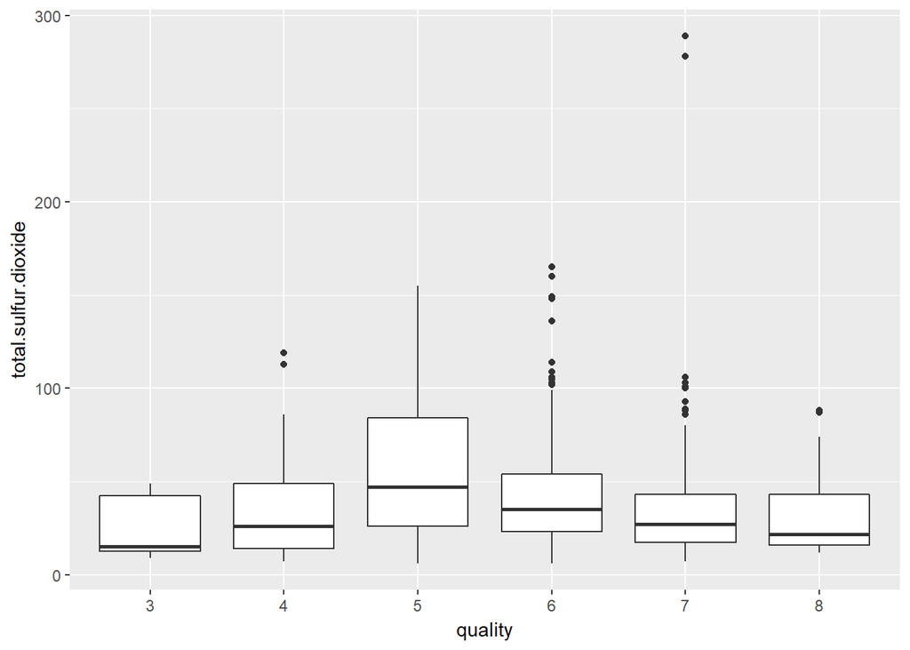

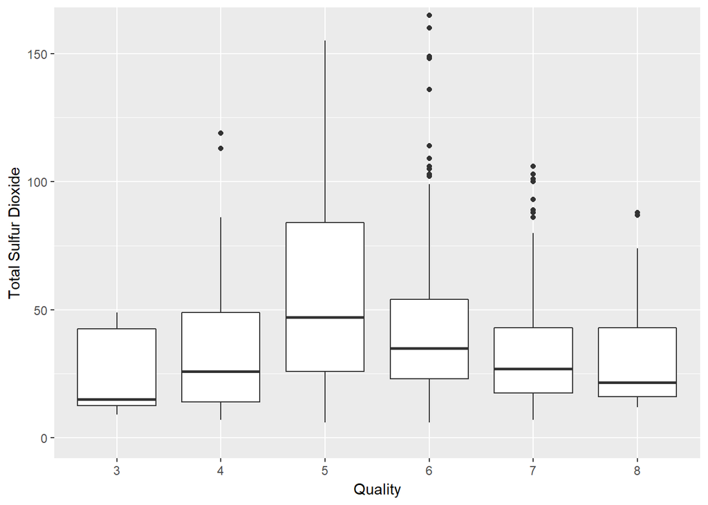

Box plots showing the weak negative correlation between total sulfur dioxide and quality. Zoomed in on the second plot. Interestingly, the lowest quality wine also has the lowest total sulfur dioxide. That might be why the correlation isn’t stronger.

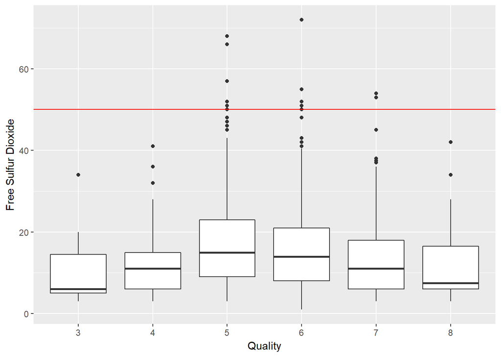

The description of the attributes mentions that concentrations of over 50 ppm free SO2 (free sulfur dioxide), its presence becomes evident in the “nose and taste” (this level is marked by a red horizontal line). From this plot, it’s hard to tell whether that’s a good or bad thing. There is supposedly a weak negative correlation between free sulfur dioxide and quality, but the plot makes me less confident in that, since on both the high and low quality ends, there tends to be lower levels of free sulfur dioxide.

# Bivariate Analysis

### Talk about some of the relationships you observed in this part of the investigation. How did the feature(s) of interest vary with other features in the dataset?

Alcohol was moderately correlated with quality (0.48), which I found surprising. The second strongest correlation was a weak negative correlation between volatile acidity and quality (-.39). That second relationship was not surprising, since wine that tastes like vinegar sounds awful.

Another surprise was that my created variable of ‘balance’ had no correlation with quality. I know that the concept of balance is very important in wine, so I think there must be more to it than my variable took into account.

### Did you observe any interesting relationships between the other features (not the main feature(s) of interest)?

The relationship between the acidities was interesting. Though one might expect them to all correlate together, that was not the case. Rather, fixed acidity (tartaric acid) and citric acid had a strong positive correlation, and volatile acidity (acetic acid) had a negative correlation with both (weak vs fixed acidity and moderate vs citric acid).

### What was the strongest relationship you found?

The strongest relationships that I found with quality were alcohol (0.48 correlation coefficient) and then volatile acidity (-0.39 correlation coefficient). After that, sulphates had a weak positive correlation with quality (0.25), as did citric acid (0.23).

# Multivariate Plots Section

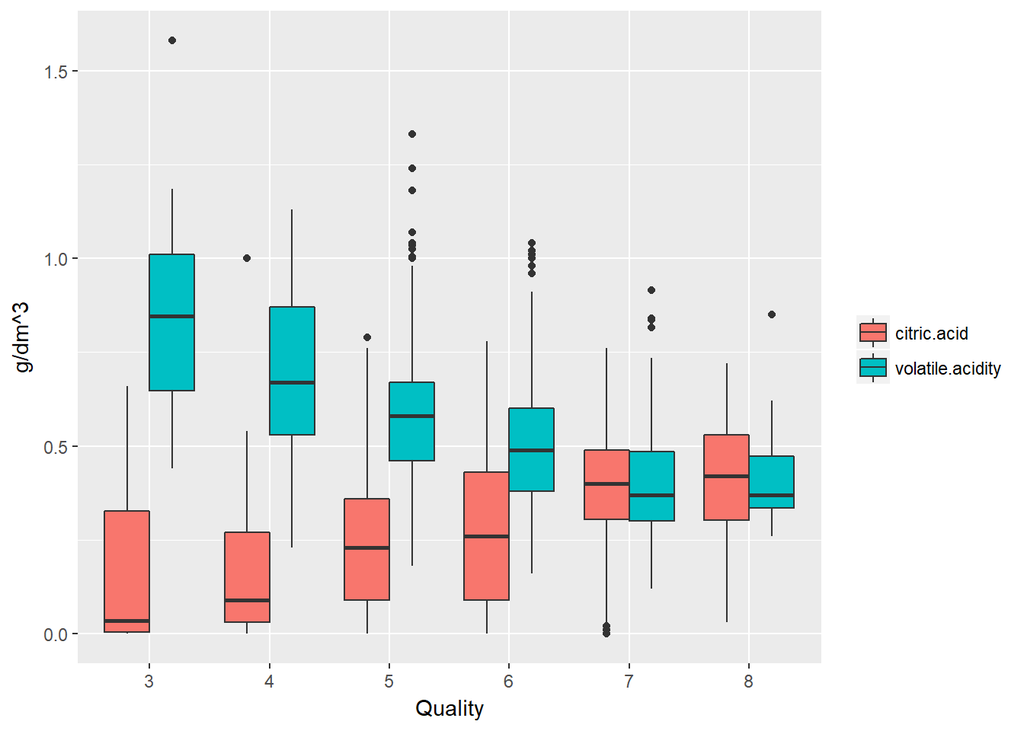

Now *that’s* interesting. As the wines get better, the amount of citric acid and acetic acid (i.e. volatile acidity) tend to be nearly equal, as the amount of acetic acid decreases, and the amount of citric acid increases. Is this what ‘balance’ *should* mean?

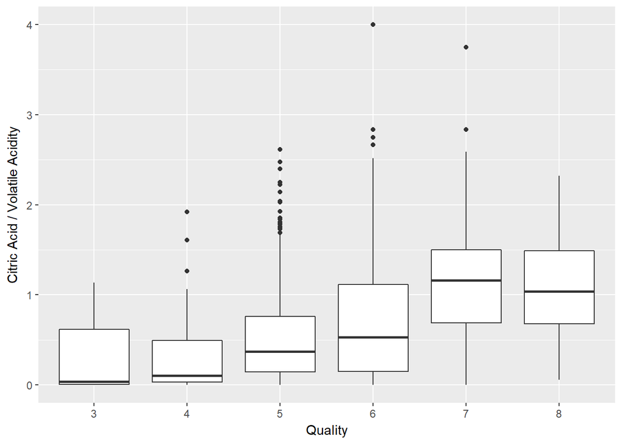

This looks somewhat promising. What’s the correlation coefficient?

```
## [1] 0.3180308
```

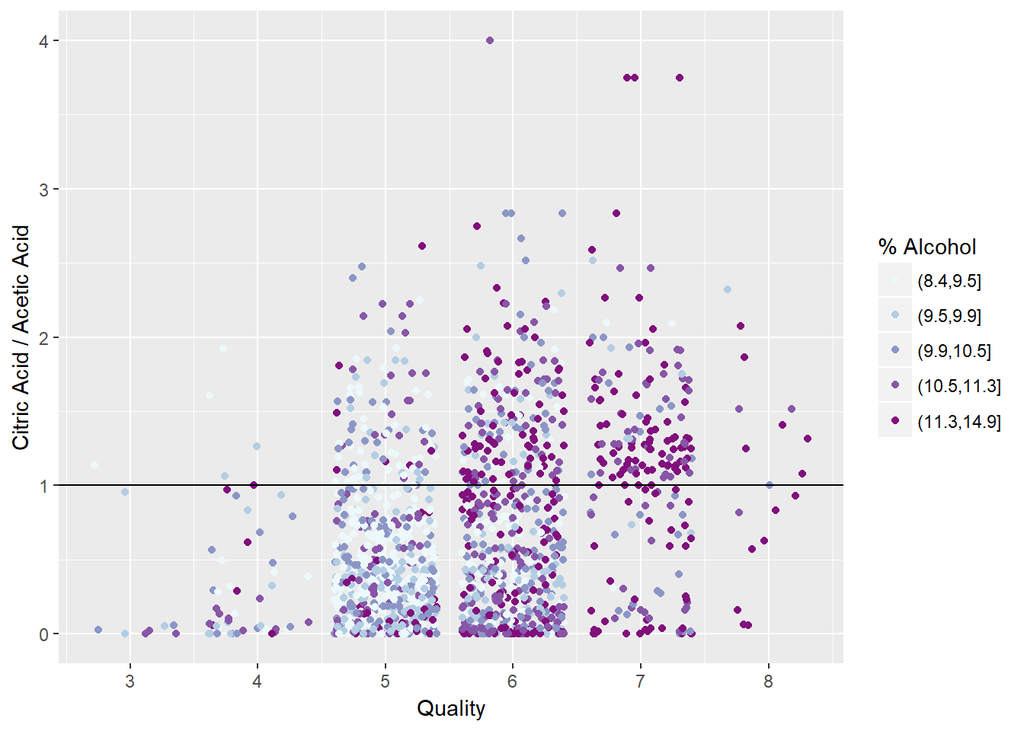

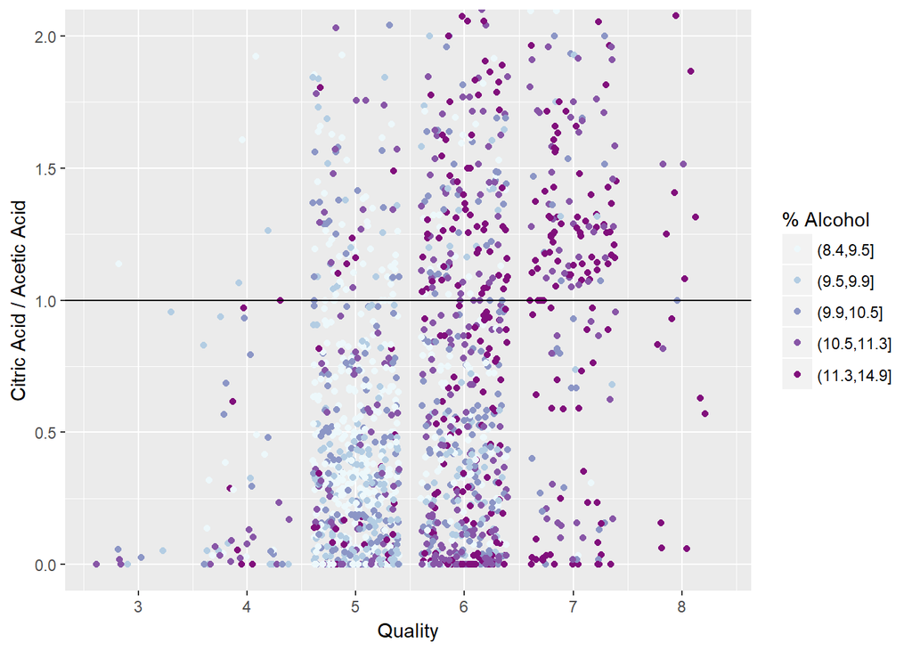

Here we see balance (citric acid/acetic acid) versus quality, with % alcohol buckets added via color. The second plot is zoomed in to get a better look at what is happening near y = 1.0. The low number of data points at the extremes makes it harder to see trends. However, between quality ratings 5 and 7, it’s clear that there’s a trend that the quality of the wine improves as the balance moves from a lower to higher ratio of citric acid to acetic acid. Most of the points with quality 5 are well below the 1.0 line, quality 6 points are more evenly spread above and below, and wines with quality 7 are predominantly above the 1.0 line.

```
##
## Calls:
## m1: lm(formula = I(quality) ~ I(alcohol), data = df)
## m2: lm(formula = I(quality) ~ I(alcohol) + balance.acidity, data = df)
## m3: lm(formula = I(quality) ~ I(alcohol) + balance.acidity + sulphates,
##     data = df)
## m4: lm(formula = I(quality) ~ I(alcohol) + balance.acidity + sulphates +
##     total.sulfur.dioxide, data = df)
## m5: lm(formula = I(quality) ~ I(alcohol) + balance.acidity + sulphates +
##     total.sulfur.dioxide + chlorides, data = df)
##
## ==============================================================================================
##                              m1            m2            m3            m4            m5
## ----------------------------------------------------------------------------------------------
##   (Intercept)               1.875***      2.025***      1.628***      1.878***      2.211***
##                            (0.175)       (0.169)       (0.176)       (0.183)       (0.189)
##   I(alcohol)                0.361***      0.327***      0.322***      0.307***      0.279***
##                            (0.017)       (0.016)       (0.016)       (0.016)       (0.017)
##   balance.acidity                         0.308***      0.248***      0.242***      0.246***
##                                          (0.028)       (0.029)       (0.029)       (0.029)
##   sulphates                                             0.732***      0.767***      1.027***
##                                                        (0.105)       (0.104)       (0.112)
##   total.sulfur.dioxide                                               -0.002***     -0.002***
##                                                                      (0.001)       (0.001)
##   chlorides                                                                        -2.392***
##                                                                                    (0.396)
## ----------------------------------------------------------------------------------------------
##   R-squared                 0.227         0.280         0.302         0.311         0.326
##   adj. R-squared            0.226         0.279         0.300         0.309         0.324
##   sigma                     0.710         0.686         0.676         0.671         0.664
##   F                       468.267       310.651       229.613       179.648       154.231
##   p                         0.000         0.000         0.000         0.000         0.000
##   Log-likelihood        -1721.057     -1663.766     -1639.626     -1629.122     -1610.991
##   Deviance                805.870       750.144       727.833       718.333       702.225
##   AIC                    3448.114      3335.533      3289.253      3270.245      3235.981
##   BIC                    3464.245      3357.041      3316.139      3302.508      3273.621
##   N                      1599          1599          1599          1599          1599
## ==============================================================================================
```

The R-sqaured value in models m1-m5 vary from 0.227 to 0.326, so I wouldn’t trust the model very far at all. I originally tried an m6, m7 and m8, adding in fixed acidity, residual sugar, and free sulfur dioxide, but they didn’t improve the model at all (the R-squared value didn’t change), so I’m leaving them out. If two models are equally accurate, choose the simpler one.

I wonder whether combining volatile acidity and citric acid made for a stronger or weaker model?

```
##
## Calls:
## m1: lm(formula = I(quality) ~ I(alcohol), data = df)
## m2: lm(formula = I(quality) ~ I(alcohol) + volatile.acidity + citric.acid,
##     data = df)
## m3: lm(formula = I(quality) ~ I(alcohol) + volatile.acidity + citric.acid +
##     sulphates, data = df)
## m4: lm(formula = I(quality) ~ I(alcohol) + volatile.acidity + citric.acid +
##     sulphates + total.sulfur.dioxide, data = df)
## m5: lm(formula = I(quality) ~ I(alcohol) + volatile.acidity + citric.acid +
##     sulphates + total.sulfur.dioxide + chlorides, data = df)
##
## ==============================================================================================
##                              m1            m2            m3            m4            m5
## ----------------------------------------------------------------------------------------------
##   (Intercept)               1.875***      3.055***      2.646***      2.843***      2.985***
##                            (0.175)       (0.194)       (0.201)       (0.205)       (0.206)
##   I(alcohol)                0.361***      0.314***      0.309***      0.295***      0.276***
##                            (0.017)       (0.016)       (0.016)       (0.016)       (0.017)
##   volatile.acidity                       -1.343***     -1.265***     -1.222***     -1.104***
##                                          (0.114)       (0.113)       (0.112)       (0.115)
##   citric.acid                             0.068        -0.079        -0.043         0.065
##                                          (0.103)       (0.104)       (0.104)       (0.106)
##   sulphates                                             0.696***      0.721***      0.908***
##                                                        (0.103)       (0.103)       (0.111)
##   total.sulfur.dioxide                                               -0.002***     -0.002***
##                                                                      (0.001)       (0.001)
##   chlorides                                                                        -1.763***
##                                                                                    (0.403)
## ----------------------------------------------------------------------------------------------
##   R-squared                 0.227         0.317         0.336         0.344         0.352
##   adj. R-squared            0.226         0.316         0.334         0.342         0.349
##   sigma                     0.710         0.668         0.659         0.655         0.651
##   F                       468.267       246.976       201.777       166.962       143.910
##   p                         0.000         0.000         0.000         0.000         0.000
##   Log-likelihood        -1721.057     -1621.596     -1599.093     -1589.749     -1580.192
##   Deviance                805.870       711.603       691.852       683.814       675.689
##   AIC                    3448.114      3253.192      3210.186      3193.499      3176.384
##   BIC                    3464.245      3280.078      3242.448      3231.138      3219.401
##   N                      1599          1599          1599          1599          1599
## ==============================================================================================
```

Combining volatile acidity and citric acid into a ‘balance’ number actually weakened the model. Here, when using them separately, we can get up to an R-squared of 0.352, an improvement of 0.026. Still not something I would rely upon, though.

# Multivariate Analysis

### Talk about some of the relationships you observed in this part of the investigation. Were there features that strengthened each other in terms of looking at your feature(s) of interest?

The most interesting relationship that I observed was when plotting both citric acid vs quality and volatile acidity vs quality at the same time. It became clear that poor wines have much more volatile acidity than citric acid, and better wines, on average, tend to have more equal amounts.

I thought that citric acid and volatile acidity might strengthen each other when put together as a calculation of ‘balance’, but they actually weakend their relationships with quality.

Another interesting relationship was between alcohol and quality. I didn’t expect to see a positive correlation between them. But, it was the strongest correlation of the bunch.

### Were there any interesting or surprising interactions between features?

### OPTIONAL: Did you create any models with your dataset? Discuss the strengths and limitations of your model.

I did create a linear model with the dataset, but it wasn’t strong. The R-value topped out at 0.352. From these chemical measurements, the quality of wine does not seem to be very predictable.

# Final Plots and Summary

### Plot One

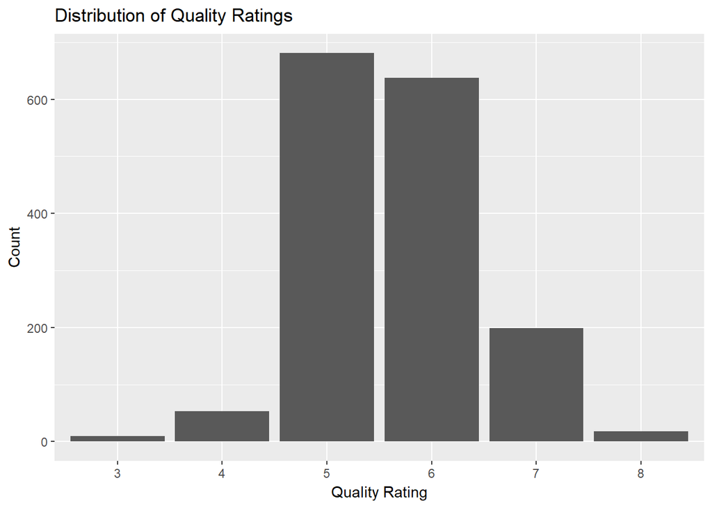

### Description One

This distribution shows that the vast majority of wines were given a quality rating of 5 or 6. In particular, this highlights one of the limitations of the data set, which is that there were so few wines at the extremes, that patterns were difficult to detect, there.

### Plot Two

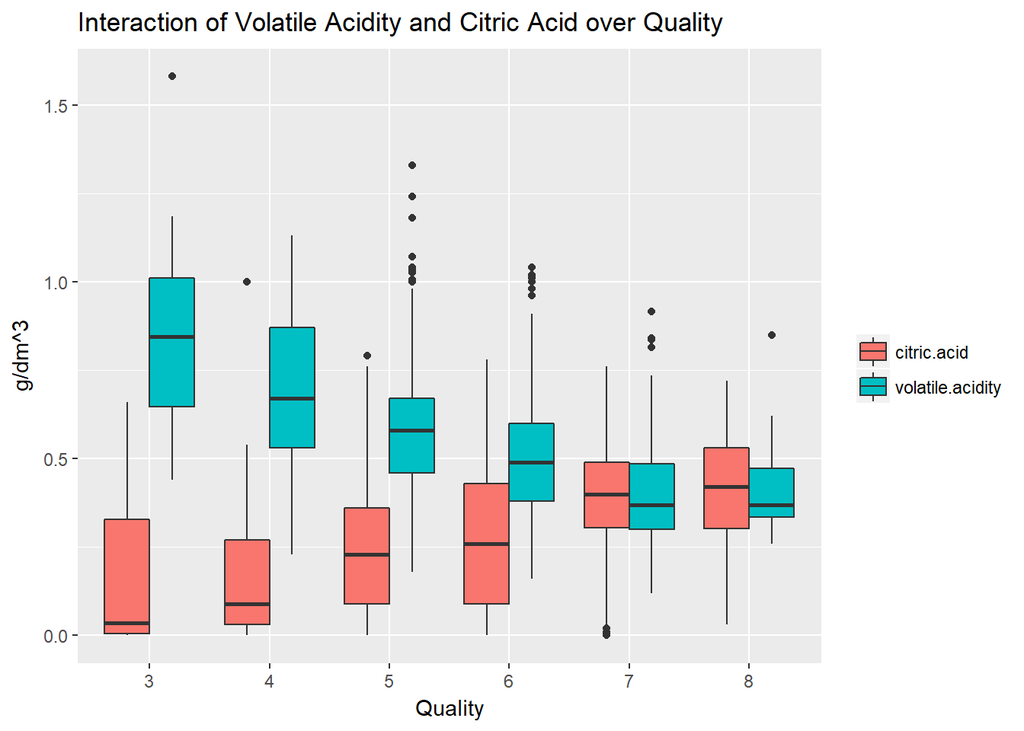

### Description Two

Wines with lower ratings tend to have much higher levels of volatile acidity compared to the levels of citric acid. As wine quality improves, these two levels tend to approach one another, and for qualities of 7 and 8, particularly, it’s clear that there is roughly a balance between the two acidities.

### Plot Three

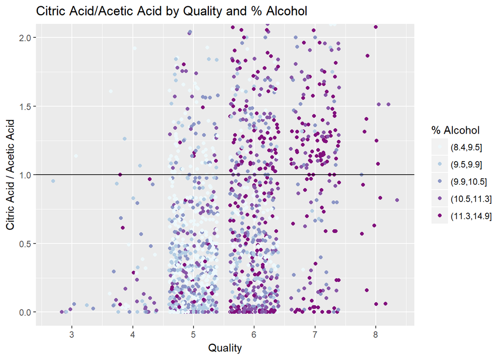

### Description Three

Higher quality ratings tend to be associated with higher percentages of alcohol, as well as higher levels of citric acid relative to volatile acidity. However, the data does not seem to support a predictive model.

# Reflection

The ‘wineQualityReds’ data set has information on 1,599 different wines, including ratings that are an average of at least three ratings given by wine experts. To begin, I took a look at variables individually, and then began to look for interesting interactions, and to find which variables had a greater impact on quality.

Wine is complex. The chemical attribute measurements of the wines clearly did not encompass all of the things that the wine experts used to make their rating. Even with a data set of 1,599 wines, the strength of detected patterns were moderate, at best. Of the attributes in the data set, percent alcohol was the strongest indicator of wine quality of the attributes measured. Another weak indicator was how much volatile acidity the wine contained (negative correlation), which had an intriguing relationship with the amount of citric acid. Better wines tended to have higher levels of citric acid, relative to the amount of volatile acidity. I tried to fit a linear model to the data, but it only accounted for 35.2% of the variance in the quality rating in this data set.

One limitation of the data set is that there were so few wines at the more extreme ratings (1-3, 8-10). This compresses the data into a small number of quality values, making it more difficult to distinguish differences and patterns. Another limitation is that quality ratings are completely subjective. Yes, they were an average of at least three ratings, but those individual ratings are based on the thoughts of an individual person, which cannot be objectively measured. For further investigation, I would try to obtain measurements of tannins, a component of wine that, when researching, I found to be quite important (4). I would also try to get a better understanding of what things make up the concept of ‘balance’ in a wine, which may include attributes not measured in this data set.

Overall, I’m not convinced that statistical tests are that helpful regarding finding high quality wines, since personal preference likely plays a large role in rating. However, measurements and statistics *would* be useful in classifying wines (sweet, dry, etc.). For example, white wine and red wine might have different chemical tendencies which would be another avenue of further inquiry. Also, statistics could possibly help in finding wines where chemical attributes are far outisde of the recommended range, and thereby assist in screening bad wines. But, I don’t truly anticipate boiling the quality of wine down to a statistical model.